# STAT636: Homework 6

#Introduction

For this assignment, let’s attempt to make a spam filter. Usually, this would involve a lot of text processing on a huge number of emails. In this case, someone has created a feature matrix for us. The feature matrix has rows given by individual emails and columns given by the number of each word or character that appears in that email, as well as three different numerical measures regarding capital letters (average length of consecutive capitals, longest sequence of consecutive capitals, and total number of capital letters).  
The supervisor, Y, is given by the user supplied label marking that email as either spam (Y = 1) or not (Y = 0). Here is a function that may be useful for this assignment:

```r
misClass =function(predClass,trueClass,produceOutput=FALSE){
  confusionMat = table(predClass,trueClass)
  if(produceOutput){
    return(1-sum(diag(confusionMat))/sum(confusionMat))
  }
  else{
    print('misclass')
    print(1-sum(diag(confusionMat))/sum(confusionMat))
    print('confusion mat')
    print(confusionMat)
  }
}
# this can be called using:
#     (assuming you make the appropriately named test predictions)
# misClass(Yhat,Y_0)
```

```r
#install.packages('randomForest')
#install.packages('gbm')
require(randomForest)
require(gbm)
require(caret)
```

Read in the R data set:

```r
load("spam.Rdata")
```

Let’s make a training and test set.

```r
train = spam$train
test  = !train
X     = spam$XdataF[train,]
X_0   = spam$XdataF[test,]
Y     = factor(spam$Y[train])
Y_0   = factor(spam$Y[test])
```

# Problem 1: Bagging and random forest (40 pts)

### Problem 1.1

To save computations, it is common to iteratively compute batches of random trees until the OOB error rate stabilizes. The following function implements does this as well as demonstrate some typical programming strategies:

```r
checkNumberItersF = function(ntrees = 5, tolParm = 1, maxIter = 10, verbose = 0){
  ###
  # tolParm: iterations will continue until the percent decrease
  #          is less than tolParm
  ###
  misClassOut   = list()
  totalTreesOut = list()

  n              = nrow(X)
  votes          = matrix(0,nrow=n,ncol=2)
  totalTrees     = 0
  iterations     = 0
  misClassOld   = 1
  while(iterations < maxIter){
    votes[is.nan(votes)] = 0
    iterations    = iterations + 1
    totalTrees    = totalTrees + ntrees
    if(verbose >= 2){cat('Total trees: ',totalTrees,'\n')}
    outRf        = randomForest(X, Y,ntree = ntrees)

    oob.times        = outRf$oob.times
    votes_iterations = outRf$votes*oob.times
    votes[oob.times>0,] = matrix(votes + votes_iterations,nrow=n)[oob.times>0,]
    if(min(apply(votes,1,sum)) == 0){next}

    Yhat          = apply(votes,1,which.max) - 1
    misClassNew  = misClass(Yhat,Y,produceOutput = TRUE)
    misClassOut[[iterations]]   = misClassNew
    totalTreesOut[[iterations]] = totalTrees
    percentChange = 100*(misClassNew - misClassOld)/misClassOld
    if(verbose >= 1){cat('% change: ',percentChange,'\n')}
    if(percentChange > -tolParm){break}
    misClassOld = misClassNew
  }
  if(iterations == maxIter){
    stop("too many iterations, try a larger ntrees or maxIter value")
  }
  return(list('misClass' = unlist(misClassOut),
              'totalTree' = unlist(totalTreesOut)))
}
```

#### Answer 1.1.1

Comment on the roll of each of these pieces in the above function. Be specific but don’t write more than 2 sentences per bullet point:

- next: SOLUTION: Go to next iteration.
- maxIter: SOLUTION: A condition keeps us from doing infinite while loop. It terminates the loop once maxIten occurs.
- verbose: SOLUTION: Show the different massages by different numbers.
- while: SOLUTION: Use while for repeating a specific block of code.
- tolParm: SOLUTION: Iterations will continue until the percent decrease is less than tolParm.
- misClassOld: SOLUTION: The initial value of misclassification and it will be replaced by real misclassification number.
- stop: SOLUTION: Stop execution of the current expression.

#### Answer 1.1.2

Call this function with a suitable value of maxIter and verbose so that the function produces the minimal amount of output. Report back the number of iterations you find

iteration = 8

```r
set.seed(1)
checkNumberIters = checkNumberItersF(maxIter = 9, verbose = 1)
```

```
## % change:  -94.32836
## % change:  -4.8583
## % change:  -5.957447
## % change:  -2.262443
## % change:  0.9259259
```

# Problem 1.2. Random Forest classifications

Fit the random forest with default m, importance, and proximity. What is the test misclassification rate, sensitivity, specificity, precision, recall, and confusion matrix for the chosen random forest? How does the test misclassification rate compare with the OOB misclassification rate?

```r
ntrees = 500 ####
outRf  = randomForest(X, Y, ntree = ntrees, mtry=if (!is.null(Y) && !is.factor(Y))
             max(floor(ncol(X)/3), 1) else floor(sqrt(ncol(X))), importance=TRUE, proximity = TRUE) ####)

#### Answer 1.2.1 Fill in the appropriate code here to define the objects.
####              Answer the questions by using the `r objectName` syntax.
####              I'll just write the first example involving test misclassification rate

class.rf = predict(outRf, X_0)

confusion_M = table(class.rf, Y_0)
testError = misClass(class.rf, Y_0, produceOutput= TRUE)#### replace with correct answer
sensitivity = sensitivity(confusion_M)
specificity = specificity(confusion_M)
precision = precision(confusion_M)
recall = recall(confusion_M)

confusion_M
```

```
##         Y_0
## class.rf   0   1
##        0 132  10
##        1   1 103
```

```r
testError
```

```
## [1] 0.04471545
```

```r
sensitivity
```

```
## [1] 0.9924812
```

```r
specificity
```

```
## [1] 0.9115044
```

```r
precision
```

```
## [1] 0.9295775
```

### Problem 1.3. Variable importance for random forests

Get a variable importance plot for the permuted OOB importance measure.

```r
#### Answer 1.3.1
head(importance(outRf,type=1))
```

```
##         MeanDecreaseAccuracy
## make                9.909928
## address            12.137611
## all                15.528728
## X3d                 6.223949
## our                28.691735
## over               15.073593
```

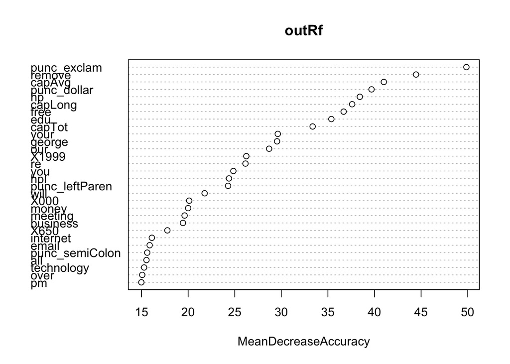

```r
varImpPlot(outRf, type = 1)
```

#### Answer 1.3.2

What is the most important feature? Punc_exclam is the most important feature.

# Problem 2: Boosting with gbm (30 pts)

There are 3 main choices involved in boosting trees: the number of boosting iterations, the learning rate, and the tree complexity [see list at end of 8.2.3 of ISL for a brief discussion].

### Problem 2.1. Boosting

Using the gbm package, explore a variety of values for these parameters in terms of the associated test misclassifciation rates. Do your conclusions change depending on if you use Adaboost versus logistics loss? (answer below in the appropriate ‘answer’ category. There are of course interactions between these tuning parameters. You can answer qualitatively, for example: ‘the test error increases as lambda increases’). Feel free to change the grids to further your investigation.

Also, if you are unfamiliar with an array, it is like a matrix but with more dimensions (a matrix is a 2 dimensional array)

```r
lambdaGrid            = c(.0001,.1,1,10)
interaction.depthGrid = c(4,5,6)
n.treesGrid           = c(500,1000)
resultsGrid           = array(0,dim=c(length(lambdaGrid),
                                      length(interaction.depthGrid),
                                      length(n.treesGrid)),
                              dimnames = list('lambda'=as.character(lambdaGrid),
                                              'interaction'=as.character(interaction.depthGrid),
                                              'n.trees'=as.character(n.treesGrid)))
resultsBoost          = list('bernoulli' = resultsGrid,
                             'adaboost'  = resultsGrid)

set.seed(1)
verbose = 0
Ychar   = as.character(Y) # gbm doesn't accept factor Y
Ychar_0 = as.character(Y_0)
for(distribution in c('bernoulli','adaboost')){
  lamIter = 0
  for(lambda in lambdaGrid){
    lamIter = lamIter + 1
    intIter = 0
    for(interaction.depth in interaction.depthGrid){
      intIter  = intIter + 1
      treeIter = 0
      for(n.trees in n.treesGrid){
        treeIter = treeIter + 1
        boostOut = gbm(Ychar~.,data=X,
                        n.trees=n.trees, interaction.depth=interaction.depth,
                        shrinkage=lambda, distribution = distribution)
        fHat  = predict(boostOut,X_0,n.trees=n.trees)
        Yhat = rep(0,nrow(X_0))
        Yhat[fHat > 0] = 1

        Yhat = as.factor(Yhat)
        if(verbose > 0){
        cat('lambda = ',lambda,' interaction.depth = ',interaction.depth, ' lambda = ',lambda,' n.trees = ',n.trees,'\n')
        }
        if(verbose > 1){
          misClass(Yhat,Ychar_0)
        }
        resultsBoost[[distribution]][lamIter,intIter,treeIter] = misClass(Yhat,Ychar_0, produceOutput = TRUE)
      }
    }
  }
}
resultsBoost
```

```
## $bernoulli
## , , n.trees = 500
##
##        interaction
## lambda           4          5          6
##   1e-04 0.45934959 0.45934959 0.45934959
##   0.1   0.03658537 0.04065041 0.04065041
##   1     0.08943089 0.06910569 0.08130081
##   10    0.78455285 0.78455285 0.47967480
##
## , , n.trees = 1000
##
##        interaction
## lambda           4          5          6
##   1e-04 0.45934959 0.45934959 0.45934959
##   0.1   0.03658537 0.02845528 0.02439024
##   1     0.07723577 0.07723577 0.07317073
##   10    0.46747967 0.58536585 0.21544715
##
##
## $adaboost
## , , n.trees = 500
##
##        interaction
## lambda           4          5          6
##   1e-04 0.45934959 0.45934959 0.45934959
##   0.1   0.02439024 0.02845528 0.02439024
##   1     0.04065041 0.03658537 0.04471545
##   10    0.47154472 0.45934959 0.18699187
##
## , , n.trees = 1000
##
##        interaction
## lambda           4          5          6
##   1e-04 0.45934959 0.45934959 0.45934959
##   0.1   0.02439024 0.02845528 0.02845528
##   1     0.05284553 0.04065041 0.04471545
##   10    0.11788618 0.18699187 0.13008130
```

#### Answer 2.1.1. How does the behavior change with Lambda?

The test errors descreased while lambda increasing at first. Then, the test erros began to increase while lambda was bigger than a number.

#### Answer 2.1.2. How does the behavior change with interaction.depth?

It seems there’s no correlation between the behavior change and interaction.depth.

#### Answer 2.1.3. How does the behavior change with n.trees?

While the number of n.trees increasing, the average losses are decreasiong.

#### Answer 2.1.4. How does the behavior change with adaboost vs. logistic loss??

The losses are overall lower of adaboost than logistic loss.

# Problem 3: Boosting vs. Random Forest (20 pts)

Choose values for the tuning parameters from boosting (except for the n.trees argument) based on your exploration in problem 2.

Make a plot of the training misclassifications and test misclassifications for a grid of ‘B’ values up to 1000 for both bagging and boosting (so, one plot with 4 curves). If you need to do a loop over a grid of ‘B’ values, you can choose a rather coarse grid (one with maybe 10 grid points). You can add more trees to gbm via gbm.more instead of recomputing the whole solution or look into predict.gbm for an easy way to get predictions over a grid. Also note that the ‘training’ and ‘test’ error from within gbm is in terms of the loss function used, not the 0-1 loss function.

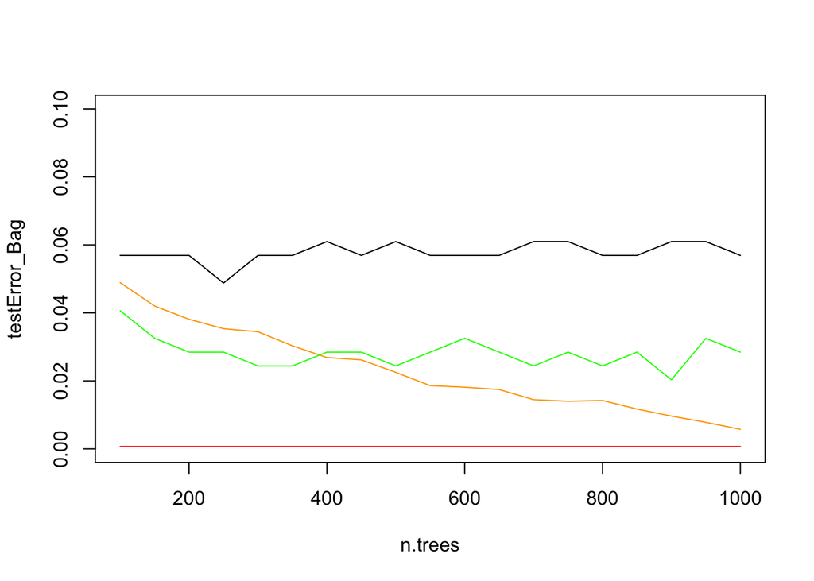

```r
#### Answer 3.1
##bagging - training & test
n.trees = seq(100,1000, by = 50)
trainingError_Bag = rep(0,length(n.trees))
testError_Bag = rep(0,length(n.trees))
i = 0
for ( B in n.trees){
  i = i+1
  outRf  = randomForest(X, Y, ntree = B, mtry= ncol(X), importance=FALSE, proximity = TRUE)
  class.rf = predict(outRf, X)
  class.rf_test = predict(outRf, X_0)
  trainingError_Bag[i] = misClass(class.rf, Y, produceOutput= TRUE)
  testError_Bag[i] = misClass(class.rf_test, Y_0, produceOutput= TRUE)
}

##boosting - - training & test
trainingError_Boost= rep(0,length(n.trees))
testError_Boost= rep(0,length(n.trees))
makePredsF = function(fHat,Y){
  Yhat     = rep(0,length(fHat))
  Yhat[fHat > 0] = 1
  return(misClass(Yhat,Y, produceOutput = TRUE))
}
j = 0
for (B in n.trees){
  j = j+1
  boostOut = gbm(Ychar~.,data=X,
                        n.trees= B, interaction.depth= 4,
                        shrinkage=0.1, distribution = 'adaboost')
  fHat_Training  = predict(boostOut,X,n.trees = B)
  fHat_Test = predict(boostOut,X_0,n.trees = B)
  trainingError_Boost[j] = makePredsF(fHat_Training,Y)
  testError_Boost[j] = makePredsF(fHat_Test,Y_0)
}

#fHat_Training  = predict(boostOut,X,n.trees = n.trees)
#fHat_Test = predict(boostOut,X_0,n.trees = n.trees)
#trainingError_Boost = apply(fHat_Training,2,makePredsF,Y)
#testError_Boost = apply(fHat_Test,2,makePredsF,Y_0)


##boosting - test
plot(n.trees,ylim = c(0,0.1),testError_Bag , type = 'l')
lines(n.trees,trainingError_Bag, col ='red')
lines(n.trees,trainingError_Boost, col ='orange')
lines(n.trees,testError_Boost, col ='green')
```

#### Answer 3.2.

Which method gets the lowest training error? The lowest test error?

Bagging has the lowest training error and boosting has the lowest test error.

# Problem 4: Boosting importance (10 pts)

Just like in bagging, we can get an idea about variable importance. For each tree in the boosting ensemble, and for each feature, we record the amount the training misclassification rate is reduced by making a split on the jth feature. We take the average of this over all B trees to get the importance. We can have R give us this information from running summary on the output of gbm and choosing the appropriate number of trees (don’t print out the importance for all features, just the largest ones)

```r
#### Answer 4.1
n.trees[which.min(testError_Boost)]
```

```
## [1] 900
```

```r
boostOut_I = gbm(Ychar~.,data=X,
                        n.trees= n.trees[which.min(testError_Boost)], interaction.depth= 4,
                        shrinkage=0.1, distribution = 'adaboost')
gbmSum = summary(boostOut_I)
```

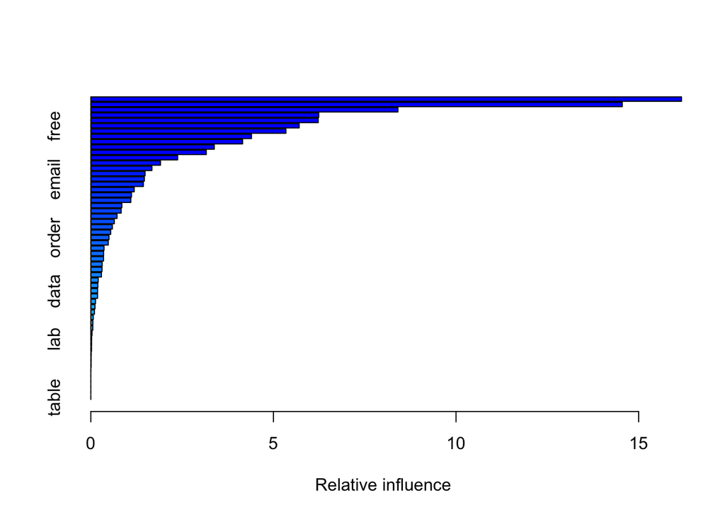

```r
head(gbmSum)
```

```
##                     var   rel.inf
## punc_exclam punc_exclam 16.173600
## punc_dollar punc_dollar 14.552318
## remove           remove  8.409012
## hp                   hp  6.242232
## capAvg           capAvg  6.227460
## free               free  5.704816
```

#### Answer 4.2.

What are the 3 most important variables? How do these compare to the 3 most important variables from Random Forest?

“Punc_exclam”, “punc_dollar” and “remove” are the 3 most important variables. From Random Forest, we could see the 3 most important variables are “punc_exclam”, “remove”, and “capAvg”, which are different from Boosting.